# The Impact of Mainline Pokémon Game Releases on Pokémon GO Player Activity

# Introduction

This project investigates whether the release of mainline Pokémon games has had a measurable impact on player activity in `Pokémon GO`. The central hypothesis is that the release of a new core Pokémon title is associated with an increase in `Pokémon GO` player activity, potentially due to renewed interest in the franchise.

To evaluate this hypothesis, two datasets are used: one containing estimated monthly `Pokémon GO` player activity since the game’s launch, and another listing the release dates of mainline Pokémon games. By comparing trends in player activity with the timing of game releases, this analysis aims to identify potential patterns or correlations between the two. We’ll also do some linear regression to identify what is the relation between the release of new games and `Pokémon Go` activity, and make some basic predictions for 2026.

###### Notes:

###### * For the purposes of this analysis, “mainline Pokémon games” refers to core series releases on Nintendo platforms, including the `Pokémon: Let’s Go` and `Pokémon: Legends` series. Spin-off titles such as `Pokémon Mystery Dungeon`, `Pokémon Sleep`, and `Pokémon UNITE` are excluded.

###### * Niantic does not publicly disclose detailed player activity metrics for `Pokémon GO`. As a result, the dataset containing estimated monthly player activity was compiled from multiple third-party sources, including [Statista](http://statista.com), [Active Player](http://activeplayer.io), and [Business of Apps](http://businessofapps.com). These figures represent approximations rather than exact values; however, they are considered sufficient for identifying high-level trends relevant to this project.

## Data

On our project we used two csv files, `estimated_go_players_monthly.csv` containing data on the MAU (Monthly Active Users) estimation since the launch of `Pokémon GO`, and `pokemon_games_release_dates.csv` containing the dates with the release dates of the Nintendo platform games.

```r
# Loading necessary libraries
library(readr)
library(dplyr)
```

```r
library(ggplot2)
library(gtrendsR)
library(lubridate) # this library allows for easier use of dates and times
# Loading the csv files into datasets
mau <- read_csv("estimated_go_players_monthly.csv")
games <- read_csv("pokemon_games_release_dates.csv")
# Previewing first 3 rows of each to make sure everything was imported correctly
head(mau, 3)
```

| Month | Estimated_Players | Milestone |
| --- | --- | --- |
| 2016-07 | 232 | All-Time Peak: Initial Global Launch |
| 2016-08 | 290 | Sustained global rollout (Central/South America) |
| 2016-09 | 160 | Buddy Pokémon System introduced |

```r
head(games, 3)
```

| Release_Date | Game_Title | Platform | Series |
| --- | --- | --- | --- |
| 2016-11-18 | Pokémon Sun | Nintendo 3DS | Main Series |
| 2016-11-18 | Pokémon Moon | Nintendo 3DS | Main Series |
| 2017-11-17 | Pokémon Ultra Sun | Nintendo 3DS | Main Series |

The dataframes seem simple and fairly clean, but looking at the data there’s some improvements that can be done, like converting the date columns to date objects and creating a boolean column for the release months.

```r
# Converting date columns to date objects
mau <- mau %>%
  mutate(Month = as.Date(paste0(Month, "-01")))

games <- games %>%
  mutate(Release_Date = as.Date(Release_Date))

# Renaming columns for clarity
mau <- mau %>%
  rename(Date = Month, Est_Players_Millions = Estimated_Players)

# Creating helper columns
games <- games %>%
  mutate(Release_Month = as.Date(format(Release_Date, "%Y-%m-01")))
mau <- mau %>%
  mutate(Is_Release_Month = Date %in% games$Release_Month)

# Previewing first 3 rows of the dataframes again
head(mau, 3)
```

| Date | Est_Players_Millions | Milestone | Is_Release_Month |
| --- | --- | --- | --- |
| 2016-07-01 | 232 | All-Time Peak: Initial Global Launch | FALSE |
| 2016-08-01 | 290 | Sustained global rollout (Central/South America) | FALSE |
| 2016-09-01 | 160 | Buddy Pokémon System introduced | FALSE |

```r
head(games, 3)
```

| Release_Date | Game_Title | Platform | Series | Release_Month |
| --- | --- | --- | --- | --- |
| 2016-11-18 | Pokémon Sun | Nintendo 3DS | Main Series | 2016-11-01 |
| 2016-11-18 | Pokémon Moon | Nintendo 3DS | Main Series | 2016-11-01 |
| 2017-11-17 | Pokémon Ultra Sun | Nintendo 3DS | Main Series | 2017-11-01 |

# Analysis

## Exploratory Data Analysis

Now that the dataframes are clean, we can start investigating. Let’s view the `Pokémon Go` player activity since launch.

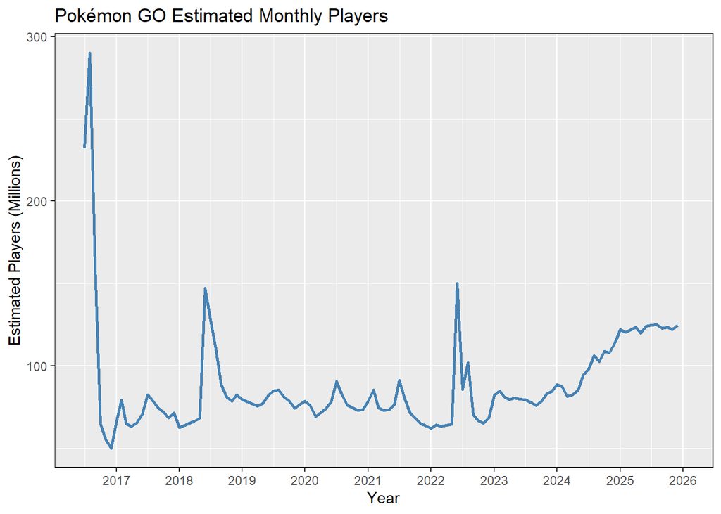

```r
go_mau_plot <- mau %>%
  ggplot(aes(Date, Est_Players_Millions)) +
  geom_line(color = "steelblue",
            size = 1) +
  scale_x_date(date_breaks = "1 year",
               date_labels = "%Y",
               limits = as.Date(c("2016-07-01", "2026-01-01"))) +
  labs(title = "Pokémon GO Estimated Monthly Players",
       x = "Year",
       y = "Estimated Players (Millions)") +
  theme(panel.border = element_rect())
go_mau_plot
```

Some curious observations can be made: - The realease of `Pokémon Go` had an extraordinary start, with average 232 Millions users on July (when the game was issuing a staggered rollout) and first month active had an average of 290 Million users worldwide, getting a [Guinness World Record](https://www.guinnessworldrecords.com/world-records/503808-most-monthly-active-users-mau-for-an-augmented-reality-ar-videogame) for it. - Every summer there seems to be a peak in activity, possibly due to more people being on leave and having more time to play and engage. - Two big summer peaks, one in 2018 and one in 2022. - User activity seems to be increasing since 2024 and have stabilised in 2025.

Let’s have a look at the in-game events for the months of May, June, July and August in 2018 and 2022:

```r
summer_events_2018_2022 <- mau %>%
  filter(Date >= "2018-05-01" & Date <= "2018-08-01" | Date >= "2022-05-01" & Date <= "2022-08-01")
summer_events_2018_2022
```

| Date | Est_Players_Millions | Milestone | Is_Release_Month |
| --- | --- | --- | --- |
| 2018-05-01 | 68.2 | Adventure Week & Alolan Forms Debut | FALSE |
| 2018-06-01 | 147.0 | 2018 Peak: Friends, Trading, & Gifts | FALSE |
| 2018-07-01 | 128.0 | 2nd Anniversary & GO Fest Chicago | FALSE |
| 2018-08-01 | 110.5 | Celebi Special Research & GO Fest Finale | FALSE |
| 2022-05-01 | 64.5 | Alolan Geodude Community Day | FALSE |
| 2022-06-01 | 150.0 | 2022 Peak: GO Fest Berlin & Season of GO launch | FALSE |
| 2022-07-01 | 85.6 | 6th Anniversary & GO Fest Seattle | FALSE |
| 2022-08-01 | 102.0 | Summer Peak: Pokémon GO Fest 2022 finale | FALSE |

The major peaks seen in the summers of 2018 and 2022 correlate with major in-game improvements as is the introduction of “Friends, Trading, & Gifts” and the launch of “Season of Go” which introduced Ultra Beasts and Ultra Wormholes to the game. This new features most likely peaked the curiosity of a big number of players who returned to the game for the holidays, but, as can be seen above, these peaks don’t match the release of any of the major games.

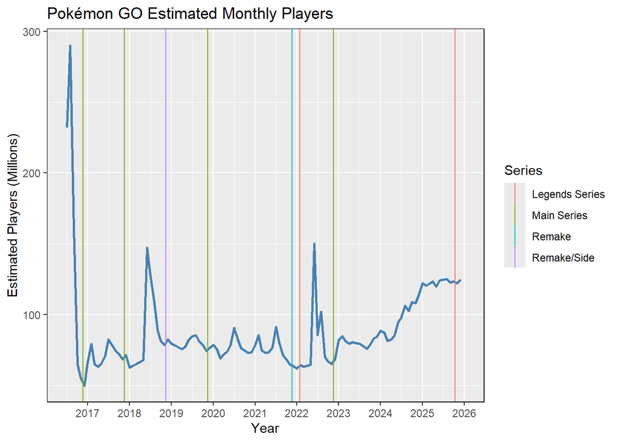

```r
go_plot_releases <- go_mau_plot +
  geom_vline(aes(xintercept = Release_Date, color = Series), data = games)
go_plot_releases
```

From the above obervations, we can see that there seems to be a small spike after the release of a game, let’s compare them by game series.

```r
# Calculating if a month is within 2 months of a game release
mau <- mau %>%
  mutate(Release_Window = sapply(Date, function(d) any(abs(as.numeric(d - games$Release_Month)) <= 62)))

# Calculating the change and change percentage in the months windows
mau <- mau %>%
  arrange(Date) %>%
  mutate(
    Change = Est_Players_Millions - lag(Est_Players_Millions),
    Percent_Change = (Est_Players_Millions - lag(Est_Players_Millions)) / lag(Est_Players_Millions) * 100)

# Filtering for the release windows
release_windows <- mau %>%
  filter(Release_Window) %>%
  select(Date, Est_Players_Millions, Change, Percent_Change, Is_Release_Month)
head(release_windows, 10)
```

| Date | Est_Players_Millions | Change | Percent_Change | Is_Release_Month |
| --- | --- | --- | --- | --- |
| 2016-09-01 | 160.0 | -130.0 | -44.827586 | FALSE |
| 2016-10-01 | 64.8 | -95.2 | -59.500000 | FALSE |
| 2016-11-01 | 55.2 | -9.6 | -14.814815 | TRUE |
| 2016-12-01 | 50.0 | -5.2 | -9.420290 | FALSE |
| 2017-01-01 | 66.5 | 16.5 | 33.000000 | FALSE |
| 2017-09-01 | 74.3 | -4.3 | -5.470738 | FALSE |
| 2017-10-01 | 72.0 | -2.3 | -3.095559 | FALSE |
| 2017-11-01 | 68.5 | -3.5 | -4.861111 | TRUE |
| 2017-12-01 | 71.2 | 2.7 | 3.941606 | FALSE |
| 2018-01-01 | 62.5 | -8.7 | -12.219101 | FALSE |

As the Dataframe has 37 rows, we’ll look at the first 10, but from this we can recognize that player activity in Pokémon GO shows variable month-to-month changes. Mainline Pokémon game releases sometimes coincide with slight increases or smaller decreases, and occasionally the month after release shows a modest uptick. Overall, there is no consistent spike pattern, suggesting that while releases may influence activity slightly, other factors likely play a larger role.

```r
# Checking changes by series type
main_series_games <- release_windows %>%
  left_join(games %>% mutate(Release_Month = as.Date(format(Release_Date, "%Y-%m-01"))) %>%
      select(Release_Month, Series),
    by = c("Date" = "Release_Month")) %>%
  distinct() %>%
  filter(Series == "Main Series")
main_series_games
```

| Date | Est_Players_Millions | Change | Percent_Change | Is_Release_Month | Series |
| --- | --- | --- | --- | --- | --- |
| 2016-11-01 | 55.2 | -9.6 | -14.814815 | TRUE | Main Series |
| 2017-11-01 | 68.5 | -3.5 | -4.861111 | TRUE | Main Series |
| 2019-11-01 | 74.2 | -4.3 | -5.477707 | TRUE | Main Series |
| 2022-11-01 | 65.2 | -1.6 | -2.395210 | TRUE | Main Series |

```r
legends_series_games <- release_windows %>%
  left_join(games %>% mutate(Release_Month = as.Date(format(Release_Date, "%Y-%m-01"))) %>%
      select(Release_Month, Series),
    by = c("Date" = "Release_Month")) %>%
  distinct() %>%
  filter(Series == "Legends Series")
legends_series_games
```

| Date | Est_Players_Millions | Change | Percent_Change | Is_Release_Month | Series |
| --- | --- | --- | --- | --- | --- |
| 2022-01-01 | 62.0 | -1.5 | -2.3622047 | TRUE | Legends Series |
| 2025-10-01 | 123.5 | 0.7 | 0.5700326 | TRUE | Legends Series |

```r
remake_series_games <- release_windows %>%
  left_join(games %>% mutate(Release_Month = as.Date(format(Release_Date, "%Y-%m-01"))) %>%
      select(Release_Month, Series),
    by = c("Date" = "Release_Month")) %>%
  distinct() %>%
  filter(Series == "Remake")
remake_series_games
```

| Date | Est_Players_Millions | Change | Percent_Change | Is_Release_Month | Series |
| --- | --- | --- | --- | --- | --- |
| 2021-11-01 | 64.8 | -3.4 | -4.985337 | TRUE | Remake |

```r
side_series_games <- release_windows %>%
  left_join(games %>% mutate(Release_Month = as.Date(format(Release_Date, "%Y-%m-01"))) %>%
      select(Release_Month, Series),
    by = c("Date" = "Release_Month")) %>%
  distinct() %>%
  filter(Series == "Remake/Side")
side_series_games
```

| Date | Est_Players_Millions | Change | Percent_Change | Is_Release_Month | Series |
| --- | --- | --- | --- | --- | --- |
| 2018-11-01 | 78.5 | -2.7 | -3.325123 | TRUE | Remake/Side |

## Using Google Trends for Analysis

We can make use of google trends to see if interest has spiked about `Pokémon Go` around the release of new games.

```r
#The code send too many requests to google and is blocking access, giving error 429.  Tried requesting by year, adding a break in between requests and reducing the terms of surch and it's still happening, so downloaded a csv file from google trends to bypass situation, will try requesting through R later

keyword <- "Pokemon Go"
start_year <- 2016
end_year <- 2025
output_file <- "pokemon_google_trends_quarterly.csv"

# Load previously fetched data if exists
if(file.exists(output_file)) {
  all_trends <- read_csv(output_file)
  all_trends <- all_trends %>%
    mutate(date = as.Date(date),
           hits = as.numeric(hits))
} else {
  all_trends <- data.frame()
}
```

```r
# Generate all year-quarter combinations
quarters <- expand.grid(year = start_year:end_year, q = 1:4)

# Check which quarters are missing
quarters$missing <- mapply(function(y, q) {
  start_month <- (q - 1) * 3 + 1
  end_month   <- start_month + 2
  start_date  <- as.Date(paste0(y, "-", sprintf("%02d", start_month), "-01"))
  end_date    <- as.Date(paste0(y, "-", sprintf("%02d", end_month), "-", days_in_month(ymd(paste0(y, "-", sprintf("%02d", end_month), "-01")))))
  !any(all_trends$date >= start_date & all_trends$date <= end_date)
}, quarters$year, quarters$q)

# If nothing missing, print message and exit
if(!any(quarters$missing)) {
  message("There's nothing to update. All quarters are already present!")
} else {
  # Loop over missing quarters only
  for(i in which(quarters$missing)) {
    y <- quarters$year[i]
    q <- quarters$q[i]

    start_month <- (q - 1) * 3 + 1
    end_month   <- start_month + 2
    start_date  <- paste0(y, "-", sprintf("%02d", start_month), "-01")
    end_date    <- paste0(y, "-", sprintf("%02d", end_month), "-", days_in_month(ymd(paste0(y, "-", sprintf("%02d", end_month), "-01"))))

    success <- FALSE
    attempts <- 0

    while(!success && attempts < 3) {
      Sys.sleep(3) # pause between requests
      attempts <- attempts + 1

      temp <- tryCatch(
        gtrends(keyword = keyword, time = paste(start_date, end_date), gprop = "web")$interest_over_time,
        error = function(e) NULL
      )

      if(!is.null(temp) && nrow(temp) > 0 && "date" %in% colnames(temp)) {
        temp <- temp %>%
          mutate(
            hits = as.numeric(ifelse(hits == "<1", 0.5, hits)),
            date = as.Date(date)
          )
        all_trends <- bind_rows(all_trends, temp)
        success <- TRUE
        message(sprintf("Fetched %s-Q%d successfully.", y, q))

        # Save progress to CSV
        write_csv(all_trends, output_file)
      } else {
        message(sprintf("Attempt %d failed for %s-Q%d. Retrying...", attempts, y, q))
        Sys.sleep(5)
      }
    }

    if(!success) message(sprintf("Failed to fetch data for %s-Q%d after 3 attempts.", y, q))
  }
}
```

```
## There's nothing to update. All quarters are already present!
```

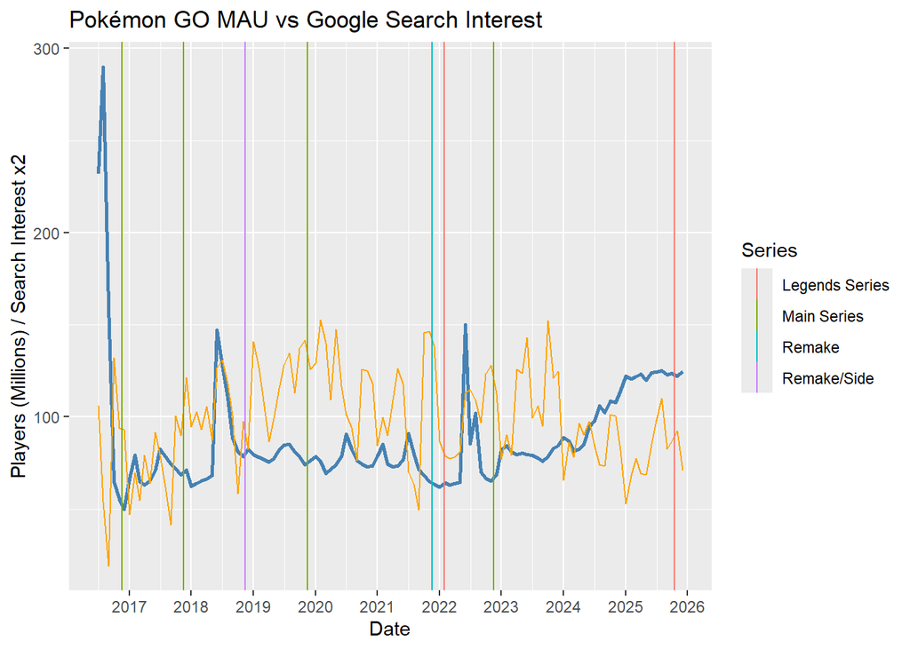

```r
# Aggregate monthly
trends_monthly <- all_trends %>%
  mutate(Month = floor_date(date, "month")) %>%
  group_by(Month) %>%
  summarise(Search_Interest = mean(hits, na.rm = TRUE)) %>%
  ungroup()

# Merge with MAU
mau_trends <- mau %>%
  left_join(trends_monthly, by = c("Date" = "Month"))

# Plot
trends_plot <- ggplot(mau_trends, aes(x = Date)) +
  geom_line(aes(y = Est_Players_Millions), color = "steelblue", size = 1) +
  geom_line(aes(y = Search_Interest * 2), color = "orange", size = 0.5) +
  labs(
    title = "Pokémon GO MAU vs Google Search Interest",
    y = "Players (Millions) / Search Interest x2",
    x = "Date"
  ) +
  scale_x_date(date_breaks = "1 year", date_labels = "%Y") +
  geom_vline(aes(xintercept = Release_Date, color = Series), data = games)
trends_plot
```

The representation of the Google queries made with the term `Pokémon Go` on them have been fairly constant with several peaks but none that correlations might be considered as with both main series games and others, the graphic shows some peaks going up while others are going down at a time of a game’s release.

## Regression

We’ll now proceed to do a linear regression to determine if the estimate number of players can be estimated from a month being in a release window.

```r
# Model 1 will estimate the average number of monthly players from months within release windows
model_1 <- lm(Est_Players_Millions ~ Release_Window, data = mau)
summary(model_1)
```

```
##
## Call:
## lm(formula = Est_Players_Millions ~ Release_Window, data = mau)
##
## Residuals:
##     Min      1Q  Median      3Q     Max
## -30.322 -15.907  -9.532   1.978 198.218
##
## Coefficients:
##                    Estimate Std. Error t value Pr(>|t|)
## (Intercept)          91.782      3.583  25.615   <2e-16 ***
## Release_WindowTRUE  -11.460      6.290  -1.822   0.0711 .
## ---
## Signif. codes:  0 '***' 0.001 '**' 0.01 '*' 0.05 '.' 0.1 ' ' 1
##
## Residual standard error: 31.44 on 112 degrees of freedom
## Multiple R-squared:  0.02879,    Adjusted R-squared:  0.02012
## F-statistic:  3.32 on 1 and 112 DF,  p-value: 0.07111
```

```r
# Model 2 separates general time trends from release window effects
mau <- mau %>%
  mutate(Month_Num = as.numeric(Date - min(Date))/30)  # approximate months since start

model_2 <- lm(Est_Players_Millions ~ Month_Num + Release_Window, data = mau)
summary(model_2)
```

```
##
## Call:
## lm(formula = Est_Players_Millions ~ Month_Num + Release_Window,
##     data = mau)
##
## Residuals:
##     Min      1Q  Median      3Q     Max
## -28.938 -16.222  -9.767   2.290 204.401
##
## Coefficients:
##                     Estimate Std. Error t value Pr(>|t|)
## (Intercept)         85.49245    6.48645  13.180   <2e-16 ***
## Month_Num            0.10351    0.08905   1.162    0.248
## Release_WindowTRUE -10.36716    6.34968  -1.633    0.105
## ---
## Signif. codes:  0 '***' 0.001 '**' 0.01 '*' 0.05 '.' 0.1 ' ' 1
##
## Residual standard error: 31.39 on 111 degrees of freedom
## Multiple R-squared:  0.04047,    Adjusted R-squared:  0.02318
## F-statistic: 2.341 on 2 and 111 DF,  p-value: 0.101
```

```r
# Model 3 estimates change with two months post release as well
mau <- mau %>%
  mutate(Is_Post_Release = lag(Release_Window, 2, default = FALSE))

model_3 <- lm(Est_Players_Millions ~ Release_Window + Is_Post_Release + Month_Num, data = mau)
summary(model_3)
```

```
##
## Call:
## lm(formula = Est_Players_Millions ~ Release_Window + Is_Post_Release +
##     Month_Num, data = mau)
##
## Residuals:
##     Min      1Q  Median      3Q     Max
## -27.286 -16.087  -9.067   5.770 200.249
##
## Coefficients:
##                      Estimate Std. Error t value Pr(>|t|)
## (Intercept)          89.67032    6.59148  13.604   <2e-16 ***
## Release_WindowTRUE   -2.71124    7.00095  -0.387   0.6993
## Is_Post_ReleaseTRUE -17.00679    7.13786  -2.383   0.0189 *
## Month_Num             0.07837    0.08786   0.892   0.3744
## ---
## Signif. codes:  0 '***' 0.001 '**' 0.01 '*' 0.05 '.' 0.1 ' ' 1
##
## Residual standard error: 30.75 on 110 degrees of freedom
## Multiple R-squared:  0.08756,    Adjusted R-squared:  0.06267
## F-statistic: 3.519 on 3 and 110 DF,  p-value: 0.01753
```

For this regression three models were constructed, model 1 does linear regression on the release window only, model 2 does a linear regression while taking into account the time trend, and model 3 looks into games post-release effects in `Pokémon GO`.

### Model Fit: Overall Time Trend

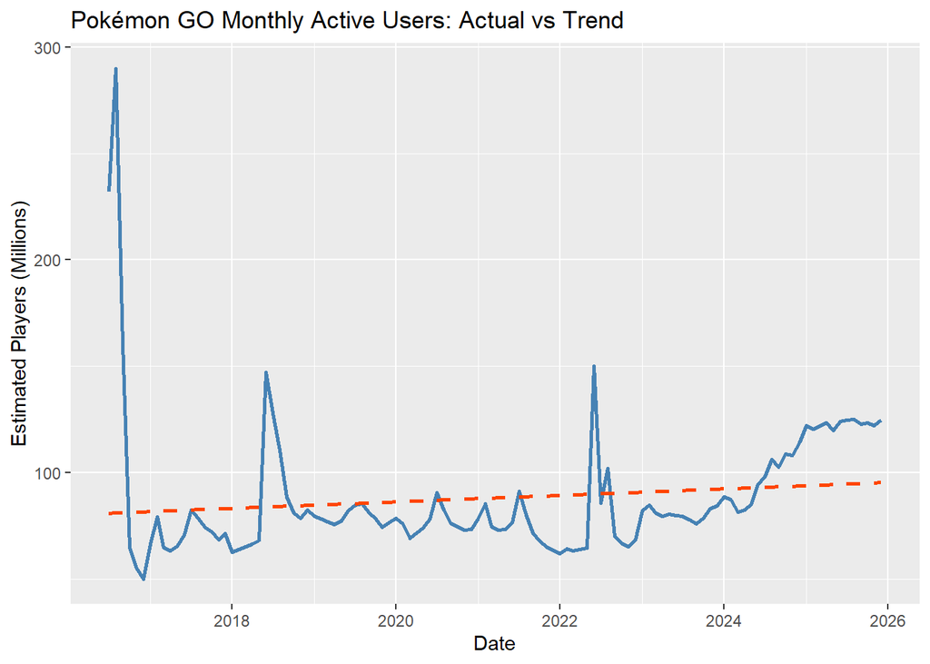

```r
# Fit simple time trend model
trend_model <- lm(Est_Players_Millions ~ Month_Num, data = mau)

# Add fitted values
mau <- mau %>%
  mutate(Fitted = fitted(trend_model))

# Plot actual vs fitted
ggplot(mau, aes(x = Date)) +
  geom_line(aes(y = Est_Players_Millions), linewidth = 1, color = "steelblue") +
  geom_line(aes(y = Fitted), linetype = "dashed", linewidth = 1, color = "orangered") +
  labs(title = "Pokémon GO Monthly Active Users: Actual vs Trend",
    x = "Date", y = "Estimated Players (Millions)")
```

**Model 3** - P-value of 0.019, meaning Post-release month is statistically significant. This means that the the first few months after the release of a mainline game actually see a drop in `Pokémon GO` player activity, suggesting players might actually be shifting their attention temporarily from `Pokémon GO` to the new game.

Summary: Linear regression analysis found no statistically significant increase in Pokémon GO monthly active users during months surrounding mainline Pokémon game releases. When accounting for post-release effects, however, player activity was significantly lower in the month following a release. This suggests that major Pokémon game launches may temporarily draw player attention away from Pokémon GO rather than stimulate increased engagement.

## 2024-2025 Regression

For comparison, we’ll also run a new regression with values only from 2024 and 2025, as to rule out the initial late 2016 spike and the effects that the Covid-19 pandemic might have, and also for the possibility to look at a player base that is now more settled.

```r
# Filtering the data
mau_2024_2025 <- mau %>%
  filter(Date >= as.Date("2024-01-01"),
         Date <= as.Date("2025-12-31"))

# Building model
model_recent <- lm(Est_Players_Millions ~ Release_Window,
  data = mau_2024_2025)
summary(model_recent)
```

```
##
## Call:
## lm(formula = Est_Players_Millions ~ Release_Window, data = mau_2024_2025)
##
## Residuals:
##     Min      1Q  Median      3Q     Max
## -24.500  -8.775   0.620  14.075  18.600
##
## Coefficients:
##                    Estimate Std. Error t value Pr(>|t|)
## (Intercept)         105.900      3.252  32.569   <2e-16 ***
## Release_WindowTRUE   17.760      7.124   2.493   0.0207 *
## ---
## Signif. codes:  0 '***' 0.001 '**' 0.01 '*' 0.05 '.' 0.1 ' ' 1
##
## Residual standard error: 14.17 on 22 degrees of freedom
## Multiple R-squared:  0.2203, Adjusted R-squared:  0.1848
## F-statistic: 6.215 on 1 and 22 DF,  p-value: 0.02068
```

```r
# Building post release model
model_recent_post <- lm(Est_Players_Millions ~ Release_Window + Is_Post_Release,
  data = mau_2024_2025)
summary(model_recent_post)
```

```
##
## Call:
## lm(formula = Est_Players_Millions ~ Release_Window + Is_Post_Release,
##     data = mau_2024_2025)
##
## Residuals:
##     Min      1Q  Median      3Q     Max
## -24.500  -8.775   0.600  14.075  18.600
##
## Coefficients:
##                     Estimate Std. Error t value Pr(>|t|)
## (Intercept)          105.900      3.328  31.820   <2e-16 ***
## Release_WindowTRUE    18.000     10.784   1.669    0.110
## Is_Post_ReleaseTRUE   -0.400     13.243  -0.030    0.976
## ---
## Signif. codes:  0 '***' 0.001 '**' 0.01 '*' 0.05 '.' 0.1 ' ' 1
##
## Residual standard error: 14.51 on 21 degrees of freedom
## Multiple R-squared:  0.2203, Adjusted R-squared:  0.1461
## F-statistic: 2.967 on 2 and 21 DF,  p-value: 0.07331
```

```r
#
```

A separate regression focusing on data from 2024 to 2025 shows a statistically significant increase in Pokémon GO monthly active users during months surrounding the release of mainline Pokémon games. This contrasts with earlier years of the dataset, where no consistent increase was observed and activity often declined in the months following a release. In the more recent data, however, this effect appears to be short-lived, as it weakens once post-release months are examined separately. Overall, this suggests that the relationship between mainline Pokémon game releases and Pokémon GO player activity has changed over time.

## 2026 Predictions

The next step is to do some predictions for 2026, do a simple linear regression prediction to get some values for March, June, September and December 2026:

```r
# Fitting the model
trend_model <- lm(Est_Players_Millions ~ Month_Num,
  data = mau)
summary(trend_model)
```

```
##
## Call:
## lm(formula = Est_Players_Millions ~ Month_Num, data = mau)
##
## Residuals:
##     Min      1Q  Median      3Q     Max
## -31.531 -15.038  -8.675   2.260 208.978
##
## Coefficients:
##             Estimate Std. Error t value Pr(>|t|)
## (Intercept) 80.89323    5.88614  13.743   <2e-16 ***
## Month_Num    0.12504    0.08872   1.409    0.161
## ---
## Signif. codes:  0 '***' 0.001 '**' 0.01 '*' 0.05 '.' 0.1 ' ' 1
##
## Residual standard error: 31.63 on 112 degrees of freedom
## Multiple R-squared:  0.01743,    Adjusted R-squared:  0.008654
## F-statistic: 1.986 on 1 and 112 DF,  p-value: 0.1615
```

```r
# Creating a tibble with the months we're interested in
future_2026 <- tibble(Date = as.Date(c(
    "2026-03-01",
    "2026-06-01",
    "2026-09-01",
    "2026-12-01"))) %>%
  mutate(Month_Num = as.numeric(difftime(Date, min(mau$Date), units = "days")) / 30.44)

# future_2026 <- future_2026 %>%
  future_2026 <- future_2026 %>%
  mutate(Predicted_MAU = predict(trend_model, newdata = future_2026), interval = "confidence")
future_2026
```

| Date | Month_Num | Predicted_MAU | interval |
| --- | --- | --- | --- |
| 2026-03-01 | 115.9658 | 95.39326 | confidence |
| 2026-06-01 | 118.9882 | 95.77117 | confidence |
| 2026-09-01 | 122.0105 | 96.14907 | confidence |
| 2026-12-01 | 125.0000 | 96.52287 | confidence |

### Projected Monthly Active Users for 2026

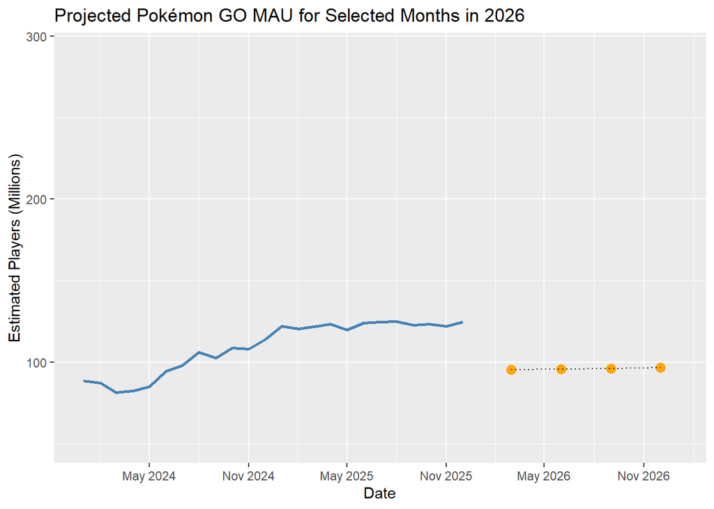

```r
# Predict values
future_2026$Predicted_MAU <- predict(trend_model, newdata = future_2026)

# Plot historical + predictions
past_future_plot <- ggplot() +
  geom_line(data = mau,
            aes(x = Date, y = Est_Players_Millions),linewidth = 1, color = "steelblue") +
  geom_point(data = future_2026, aes(x = Date, y = Predicted_MAU), size = 3, color = "orange") +
  geom_line(data = future_2026, aes(x = Date, y = Predicted_MAU), linetype = "dotted") +
  labs(title = "Projected Pokémon GO MAU for Selected Months in 2026",
    x = "Date", y = "Estimated Players (Millions)") +
  scale_x_date(limits = as.Date(c("2024-01-01", "2026-12-31")),
               date_breaks = "6 months", date_labels = "%b %Y")
past_future_plot
```

# Conclusion and Further Work

At the start of this project, my assumption was that whenever a new Pokémon game came out, there would be a slight spike in `Pokémon Go` player activity, as this would regenerate interest in the franchise, but the analysis conducted with this project actually reflects the opposite: That player engagement tends to have a dip during and shortly after a new game comes out, and from here, one can extrapolate that it’s actually the new games that temporarily take attention away from `Pokémon Go`. We also make the discovery that in the last couple of years, not only has the `Pokémon Go` game seen an increase and then stabilizing of its player base, but the trend observed actually flipped, with `Pokémon Go` seing a small increase shortly after a new mainline game comes out. We could also confirm that the release of new games has little to no effect in google searches for `Pokémon Go`. With the data that we have available to us, it was possible to make some predictions for 2026, that would put the MAU (Monthly Active Users) close to 95 Million users for each trimester.

Going forward, it would be ideal to conduct this reasearch with official numbers released by Niantic, and some other Pokemon related queries in Google trends.